# Motor Trend: Automatic vs. Manual Transmission

Dax Gerts

July 20, 2015

## Executive Summary

This report examines the data provided by R’s `mtcars` dataset, originally collected by the Motor Trend US magazine in 1974. `mtcars` details the miles per gallon rating and 10 other aspects of car design obtained from observation of 32 automobiles.

In this report, we will attempt to answer the question of whether automatic or manual transmission provide higher miles per gallon, and in doing so will attempt to quantify those differences.

## Exploratory Analysis

The data was first extracted from `mtcars` being preprocessed for analysis.

```r
## Load and store dataset, "mtcars"
library(datasets)
data(mtcars)
cars <- mtcars
## Factor variables converted from numeric
cars$cyl <- as.factor(cars$cyl)
cars$vs <- as.factor(cars$vs)
cars$am <- as.factor(cars$am)
cars$gear <- as.factor(cars$gear)
cars$carb <- as.factor(cars$carb)
```

Some basic exploratory analyses were conducted as follows. Please consult the Appendix for the graphical results.

```r
library(ggplot2)
## Histogram (MPG Distribution), Appendix.1
ggplot(cars,aes(x=mpg)) +
  geom_histogram(binwidth=1) +
  ggtitle("MPG Distribution") +
  xlab("Miles pegr Gallon (MPG)") +
  ylab("Frequency")
## Boxplot: Manual vs. Automatic Transmission by MPG, Appendix.2
boxplot(mpg~am,cars,title="Manual vs. Automatic Transmission by MPG",xlab="Transmission",ylab="MPG",names=c("Automatic","Manual"))
```

These results suggested that manual and automatic transmission yield distinct results in mpg, and that manual transmission tends to resut in higher mpg values. This was verified quantitatively by taking a t test of the relation between mpg and transmission.

```r
t.test(cars$mpg ~ cars$am)$p.value
```

```
## [1] 0.001373638
```

```r
t.test(cars$mpg ~ cars$am)$estimate
```

```
## mean in group 0 mean in group 1
##        17.14737        24.39231
```

A a p-value of 0.00137 is sufficiently low enough to reject the null hypothesis, verifying the factors are unique populations. This is further verified by the approximately 7 mpg difference between automatic and manual transmissions.

```

## Appendix

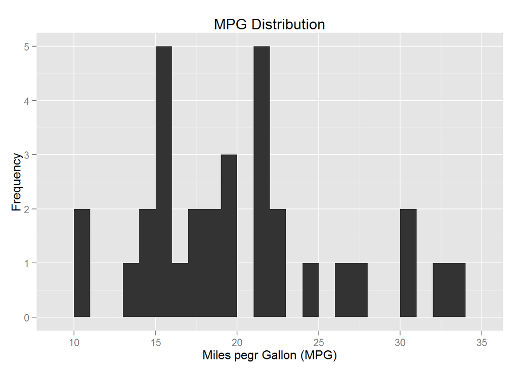

```r
## Histogram (MPG Distribution)
library(ggplot2)
ggplot(cars,aes(x=mpg)) +
  geom_histogram(binwidth=1) +
  ggtitle("MPG Distribution") +
  xlab("Miles pegr Gallon (MPG)") +
  ylab("Frequency")
```

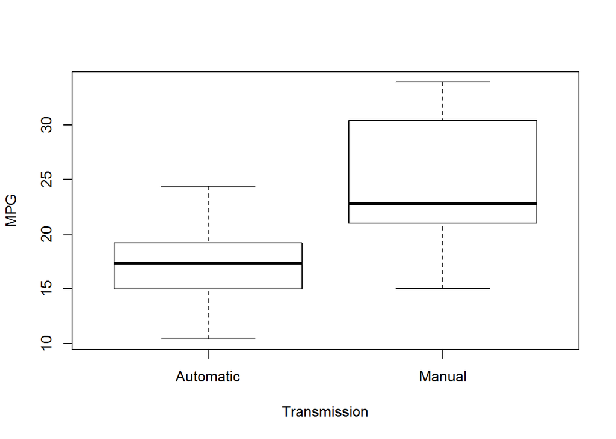

```r
## Boxplot: Manual vs. Automatic Transmission by MPG
boxplot(mpg~am,cars,title="Manual vs. Automatic Transmission by MPG",xlab="Transmission",ylab="MPG",names=c("Automatic","Manual"))
```